# 5 janvier 2023

# on a 55 descripteurs

# 5. En se basant sur les poids synaptique, réalisez un ordonnancement de

l’importance des caractéristiques. Justifiez la faisabilité de l’ordonnancement des caractéristiques à partir des poids synaptiques.

```python
car = perceptron.coef_
car
cdf=pd.DataFrame(columns = ['variable','poids'])
j = -1
for i in  perceptron.coef_:
    for a in i:
        j = j+1
        cdf.loc[j]=[df.columns[j],a]
```

```python
cdf.sort_values(by = 'poids')
```

|  | variable | poids |
| --- | --- | --- |
| 24 | wf_hp | -150.460000 |
| 37 | wf_direct | -103.060000 |
| 39 | wf_meeting | -99.570000 |
| 43 | wf_edu | -84.810000 |
| 32 | wf_85 | -74.280000 |
| 46 | cf_comma | -64.514000 |
| 25 | wf_hpl | -60.240000 |
| 30 | wf_data | -57.450000 |
| 28 | wf_telnet | -56.230000 |
| 45 | wf_conference | -50.870000 |
| 41 | wf_project | -48.870000 |
| 38 | wf_cs | -47.730000 |
| 26 | wf_lab | -45.180000 |
| 42 | wf_re | -40.000000 |
| 34 | wf_1999 | -38.570000 |
| 40 | wf_original | -34.150000 |
| 9 | wf_mail | -32.888889 |
| 48 | cf_sqbracket | -32.647000 |
| 54 | capital_run_length_total | -29.414634 |
| 36 | wf_pm | -28.780000 |
| 47 | cf_bracket | -23.730159 |
| 27 | wf_labs | -13.430000 |
| 44 | wf_table | -9.570000 |
| 29 | wf_857 | -8.280000 |
| 21 | wf_font | -7.010000 |
| 31 | wf_415 | -6.970000 |
| 0 | wf_make | -6.730000 |
| 10 | wf_receive | -5.910000 |
| 12 | wf_people | -2.620000 |
| 11 | wf_will | 0.075949 |
| 35 | wf_parts | 1.800000 |
| 20 | wf_your | 2.676923 |
| 1 | wf_address | 4.050000 |
| 51 | cf_hash | 4.664000 |
| 23 | wf_money | 5.690000 |
| 15 | wf_free | 7.250000 |
| 17 | wf_email | 8.140000 |
| 8 | wf_order | 11.790000 |
| 53 | capital_run_length_longest | 13.666667 |
| 13 | wf_report | 15.520000 |
| 2 | wf_all | 21.095238 |
| 18 | wf_you | 28.235741 |
| 49 | cf_exclam | 29.231481 |
| 5 | wf_over | 29.570000 |
| 50 | cf_dollar | 33.192982 |
| 3 | wf_3d | 38.180000 |
| 14 | wf_addresses | 38.850000 |
| 4 | wf_our | 40.641026 |
| 33 | wf_technology | 47.170000 |
| 19 | wf_credit | 52.870000 |
| 16 | wf_business | 83.510000 |
| 7 | wf_internet | 89.310000 |
| 22 | wf_000 | 90.920000 |
| 6 | wf_remove | 141.210000 |
| 52 | capital_run_length_average | 423.124186 |

```python
perceptron.intercept_
```

```
array([-45.])
```

# 6. Représentez graphiquement l’importance des caractéristiques. Interprétez

les résultats. Quelles sont les caractéristiques les plus importantes (discriminantes). 2

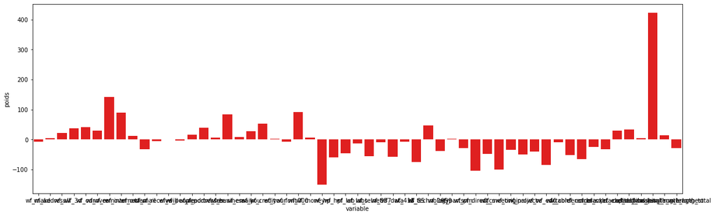

```python
fi = plt.subplots(figsize=(20,6))
sns.barplot(x="variable",y="poids",data=cdf ,color='red')
plt.show()
```

# 7 . En utilisant la libraire Sklearn, développez un perceptron multicouche

(hidden_layer_sizes=(2),activation=’logistic’,random_state=100 ,max_iter=1500).

```python
import numpy as np
from sklearn.neural_network import MLPClassifier


# Creation  du modèle de perceptron multicouche
mlp = MLPClassifier(hidden_layer_sizes=(2), activation='logistic',  random_state=100, max_iter=1500)

# on entraine le modèle sur les données d'entraînement
mlp.fit(X_train, y_train)

# on Évalue le modèle sur les données de test
accuracy = mlp.score(X_test, y_test)
print("Accuracy: ", accuracy)
```

```
Accuracy:  0.915
```

# 8. Représentez la matrice de confusion et évaluez les performances.

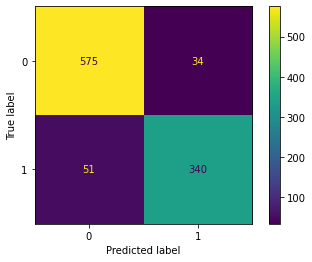

```python
mat_confu =metrics.plot_confusion_matrix(mlp,X_test,y_test)
```

# 9 .comparez les performances du perceptron simple avec le perceptron multicouche :

```python
print(f"le score du perceptron multicouche est   : {mlp.score(X_test,y_test)}")
print(f"le nscore du perceptron simple  est : {perceptron.score(X_test,y_test)}")
```

```
le score du perceptron multicouche est   : 0.915
le nscore du perceptron simple  est : 0.852
```

# les performances :

```python
from sklearn.metrics import classification_report
#performances perceptron simple
per= perceptron.predict(X_test)

print(classification_report(y_test,per))
```

```
              precision    recall  f1-score   support

           0       0.90      0.85      0.87       609
           1       0.78      0.86      0.82       391

    accuracy                           0.85      1000
   macro avg       0.84      0.85      0.85      1000
weighted avg       0.86      0.85      0.85      1000
```

```python
#performances multicouches
ppper= mlp.predict(X_test)
print(classification_report(y_test,ppper))
```

```
              precision    recall  f1-score   support

           0       0.92      0.94      0.93       609
           1       0.91      0.87      0.89       391

    accuracy                           0.92      1000
   macro avg       0.91      0.91      0.91      1000
weighted avg       0.91      0.92      0.91      1000
```

# on remarque que les performance dans le perceptron multicouche est bcp plus elevee que le perceptron simple

# 10 .la variation de la fonction perte du perceptron multicouches en fonction du nombre díteration :

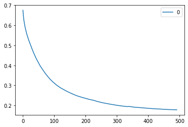

```python
pd.DataFrame(mlp.loss_curve_).plot()
```